# Bulletin Covid

V. Tolon & V. Payet

03 mai 2022

## R Markdown

Nous utilisons ici des données publiques (accès et utilisation libre) et de taille suffisamment restreintes pour être contenues dans un seul fichier de type *.txt* ou *.csv*. Vous pouvez trouver ces données avec un moteur de recherche classique ou sur des sites spécialisés dans la mise à disposition de données publiques.

- Vous pourrez par exemple aller sur https://www.data.gouv.fr/fr/ puis faire une recherche avec *covid pays monde évolution*. Ouvrez le lien présentant l’évolution de la pandémie du Covid19 dans le monde sur les 30 derniers jours, allez en bas de la page pour cliquer sur le lien *Evolution par jour et par pays (CSV)*, copier l’adresse de l’URL et utilisez la dans l’import :

```r
covid<-read.csv2("https://www.data.gouv.fr/fr/datasets/r/f4935ed4-7a88-44e4-8f8a-33910a151d42" ,
                 header=TRUE, dec=".", sep=";",
                 skip=7, encoding = "UTF-8")
# Attention nous ne lisons pas les 3 première lignes grâce à skip=3
# Il s'agissait de 3 lignes de présentation des données
# Nous spécifions aussi l'encodage en UTF-8 (gestion des accents)
dim(covid)
```

```
## [1] 6417    8
```

```r
covid[1:4, 1:5]
```

```
##         Date               Pays Infections Deces Guerisons
## 1 2022-05-03            Albanie     275177  3496         0
## 2 2022-05-03 Bosnie-Herzégovine     377087 15765         0
## 3 2022-05-03            Bahreïn     569370  1476         0
## 4 2022-05-03            Bolivie     905074 21923         0
```

```r
covid$Date<-as.POSIXct(covid$Date,format="%Y-%m-%d")
```

# En Chine

## Nb Cas

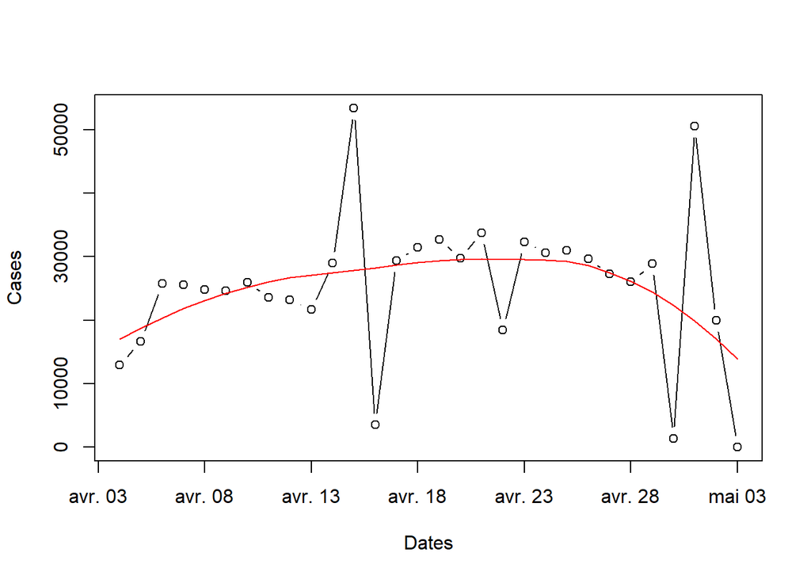